# Estructuras de datos Abstractas y Algoritmos\

# Tarea# 3

# Royer Méndez Ramírez - A43333

# Ejercicio #1

## Parte1.a

Dado lista1 = [13,2,104,36,9,120,29,500,89,41,65,7]\ diccionario = {0:20,1:320,2:90,3:147,4:122,5:717,6:2,7:77,8:112,9:14,10:17,11:24}

```python
# TAREA#3 - ROYER MÉNDEZ RAMÍREZ
# EJERCICIO#1. PARTE A

#Se crea la función
def calculos(lista1, diccionario):


    lista_de_salida = [] # Se crea una lista vacia

    for elemento in (lista1):
        lista_de_salida.append(elemento) #Se agregan los elementos de la lista a la lista vacía

    for value in diccionario.values():
            lista_de_salida.append(value) #Se agregan los elementos de los valores del diccionario a la lista vacía

    lista_de_salida.sort() #Se ordena en orden ascendente de sus elementos

    return lista_de_salida


#El llamado a la función

lista1 = [13, 2, 104, 36, 9, 120, 29, 500, 89, 41, 65, 7]
diccionario = {0:20, 1:320, 2:90, 3:147, 4:122, 5:717, 6:2, 7:77, 8:112, 9:14, 10:17, 11:24}

lista = calculos(lista1, diccionario)

print(lista)
```

```
[2, 2, 7, 9, 13, 14, 17, 20, 24, 29, 36, 41, 65, 77, 89, 90, 104, 112, 120, 122, 147, 320, 500, 717]
```

## Parte1.B

Usando las bibliotecas vistas en clase calcular para la lista y para los valores del diccionario: la media, la desviación estándard y la mediana (investigar como se calcula)

```python
# TAREA#3 - ROYER MÉNDEZ RAMÍREZ
# EJERCICIO#1. PARTE B

import numpy as np

lista1 = [13, 2, 104, 36, 9, 120, 29, 500, 89, 41, 65, 7]
lista1.sort()   #Se ordena la lista en orden ascendente de sus elementos


diccionario = {0:20, 1:320, 2:90, 3:147, 4:122, 5:717, 6:2, 7:77, 8:112, 9:14, 10:17, 11:24}

valores_diccionario = [] #Decidí crear una lista con los valores del diccionario

for valor in diccionario.values():
    valores_diccionario.append(valor)

valores_diccionario.sort()  #Se ordena en orden ascendente de sus elementos


def calculos_estadisticos (lista1, valores_diccionario):

    #Media y desviacion estandar para la lista y el diccionario, respectivamente
    media_lista = np.mean(lista1)
    desviacion_estandar_lista = np.std(lista1)
    media_diccionario = np.mean(valores_diccionario)
    desviacion_estandar_diccionario = np.std(valores_diccionario)


    ###CALCULOS PARA OBTENER LA MEDIANA DE LA LISTA MANUALMENTE###
    contador = 0

    for i in range (0, len(lista1)):
        contador += 1

    numero_total_elementos = contador  #son 12 elementos

    elemento_izq = (numero_total_elementos/2)-1 #elemento 05 de la lista
    elemento_der = (numero_total_elementos/2) #elemento 06 de la lista

    valor_izq = lista1[int(elemento_izq)]   #El valor que esta contenido en el elemento 05 de la lista (36)
    valor_der = lista1[int(elemento_der)]   #El valor que esta contenido en el elemento 06 de la lista (41)

    mediana_lista = (valor_izq + valor_der)/2


    ###CALCULOS PARA OBTENER LA MEDIANA DEL DICCIONARIO MANUALMENTE###
    contador = 0

    for i in range (0, len(valores_diccionario)):
        contador += 1

    numero_total_elementos = contador  #son 12 elementos

    elemento_izq = (numero_total_elementos/2)-1 #elemento 05 de la lista
    elemento_der = (numero_total_elementos/2) #elemento 06 de la lista

    valor_izq = valores_diccionario[int(elemento_izq)]   #El valor que esta contenido en el elemento 05 de la lista (77)
    valor_der = valores_diccionario[int(elemento_der)]   #El valor que esta contenido en el elemento 06 de la lista (90)

    mediana_diccionario = (valor_izq + valor_der)/2

    return media_lista, desviacion_estandar_lista, mediana_lista, media_diccionario, desviacion_estandar_diccionario, mediana_diccionario


    #Llamado a la funcion

valores_estadisticos = calculos_estadisticos(lista1, valores_diccionario)

print("\nLos valores estadisticos de la lista1 son: \n\t Media: ",valores_estadisticos[0], "\n\t Desviación estandar: ",valores_estadisticos[1], "\n\t Mediana: ",valores_estadisticos[2], "\n\nLos valores estadisticos del diccionario son: \n\t Media: ",valores_estadisticos[3], "\n\t Desviación estandar: ",valores_estadisticos[4], "\n\t Mediana: ",valores_estadisticos[5])



###MANERA FACIL PARA OBTENER LA MEDIANA DE LA LISTA1 Y DE LOS VALORES DEL DICCIONARIO###

mediana_lista_prueba = np.median(lista1)
mediana_diccionario_prueba = np.median(valores_diccionario)

#print(mediana_lista_prueba, mediana_diccionario_prueba)  #son los mismos valores de arriba
```

```
Los valores estadisticos de la lista1 son:
	 Media:  84.58333333333333
	 Desviación estandar:  130.9042005522444
	 Mediana:  38.5

Los valores estadisticos del diccionario son:
	 Media:  138.5
	 Desviación estandar:  193.82831750460682
	 Mediana:  83.5
```

## Parte1.C

Haga una copia de la lista y una copia del diccionario y hacer una función en Python que tome los llaves del diccionario y los valores en la lista y devuelver un diccionario.

```python
# TAREA#3 - ROYER MÉNDEZ RAMÍREZ
# EJERCICIO#1. PARTE C

lista1 = [13, 2, 104, 36, 9, 120, 29, 500, 89, 41, 65, 7]
diccionario = {0:20, 1:320, 2:90, 3:147, 4:122, 5:717, 6:2, 7:77, 8:112, 9:14, 10:17, 11:24}

lista1_copia = lista1 [:] #Se hace una copia de la lista
diccionario_copia = diccionario.copy() #Se hace una copia del diccionario


#Se crea la funcion para el nuevo diccionario
def diccionario_nuevo(diccionario_copia, lista1_copia):

    nuevo_diccionario = dict(zip(diccionario_copia, lista1_copia)) #Se unen los elementos de la lista y de las llaves del diccionario

    return nuevo_diccionario


#Llamado a la funcion

diccionario_nuevo = diccionario_nuevo(diccionario_copia.keys(), lista1_copia)

print(diccionario_nuevo)
```

```
{0: 13, 1: 2, 2: 104, 3: 36, 4: 9, 5: 120, 6: 29, 7: 500, 8: 89, 9: 41, 10: 65, 11: 7}
```

# Ejercicio #2

## Parte a:

Construir una tabla con pandas a partir del siguiente diccionario. La construcción debe contener un índice de tipo string, provisto por el estudiante. ej. “est1”, “est2”, …

```python
from audioop import reverse #Se va a necesitar en la parte 2d
import pandas as pd
from numpy import mean, std

datos = {'Nombre': ["Marco", "Francisco", "Roberto", "Mariel", "Sonia", "John", "Charles"],
         'Carrera':["Ing. Eléctrica", "Educación Física", "Matemáticas", "Ing. Mecánica", "Derecho", "Idiomas", "Ing. Civil"],
         'Edad':["21", "20", "19", "29", "22", "21", "22"]}

#Parte 2.A -- Agregar los indices a la Tabla de Datos
tabla = pd.DataFrame(datos, index = ["Est 1", "Est 2", "Est 3", "Est 4", "Est 5", "Est 6", "Est 7"])
```

## Parte b:

Imprimir la tabla convertida con Pandas a consola.

```python
#Parte 2.B -- Imprimir la Tabla de Datos

print (tabla)
```

```
          Nombre           Carrera Edad
Est 1      Marco    Ing. Eléctrica   21
Est 2  Francisco  Educación Física   20
Est 3    Roberto       Matemáticas   19
Est 4     Mariel     Ing. Mecánica   29
Est 5      Sonia           Derecho   22
Est 6       John           Idiomas   21
Est 7    Charles        Ing. Civil   22
```

## Parte c:

Ordenar la tabla por nombre (ascendente)

```python
#Parte 2.C -- Imprimir por "Nombre" ascendente
tabla.sort_values(by=['Nombre'])
print (tabla.sort_values(by=['Nombre']))
```

```
          Nombre           Carrera Edad
Est 7    Charles        Ing. Civil   22
Est 2  Francisco  Educación Física   20
Est 6       John           Idiomas   21
Est 1      Marco    Ing. Eléctrica   21
Est 4     Mariel     Ing. Mecánica   29
Est 3    Roberto       Matemáticas   19
Est 5      Sonia           Derecho   22
```

## Parte d:

```python
#Parte 2.D -- Imprimir por "Carrera" descendente
tabla.sort_values(by=['Carrera'], ascending=False)
print (tabla.sort_values(by=['Carrera'], ascending=False))
```

```
          Nombre           Carrera Edad
Est 3    Roberto       Matemáticas   19
Est 4     Mariel     Ing. Mecánica   29
Est 1      Marco    Ing. Eléctrica   21
Est 7    Charles        Ing. Civil   22
Est 6       John           Idiomas   21
Est 2  Francisco  Educación Física   20
Est 5      Sonia           Derecho   22
```

## Parte e:

Deben hacer la visualización usando el índice binario de los cuatro primeros estudiantes.

```python
#Parte 2.E -- Visualizacion por medio de indice binario (iloc) de los 4 primeros estudiantes

print(tabla.iloc[0:4,:])
```

```
          Nombre           Carrera Edad
Est 1      Marco    Ing. Eléctrica   21
Est 2  Francisco  Educación Física   20
Est 3    Roberto       Matemáticas   19
Est 4     Mariel     Ing. Mecánica   29
```

## Parte f:

Deben hacer la visualización usando el índice textual de los estudiantes a partir de la segunda entrada.

```python
#Parte 2.F -- Visualizacion por medio de indice textual (loc) de estudiantes a partir de la 2da entrada

print(tabla.loc['Est 2':,:])
```

```
          Nombre           Carrera Edad
Est 2  Francisco  Educación Física   20
Est 3    Roberto       Matemáticas   19
Est 4     Mariel     Ing. Mecánica   29
Est 5      Sonia           Derecho   22
Est 6       John           Idiomas   21
Est 7    Charles        Ing. Civil   22
```

## Parte g:

Deben mostrar para los estudiantes de las posiciones binarias 3,4,5 de los datos de carrera y edad únicamente.

```python
#Parte 2.G -- Para estudiantes de las posiciones binarias 3,4,5 mostrar datos de carrera y edad

print(tabla.iloc[3:6,1:3])
```

```
             Carrera Edad
Est 4  Ing. Mecánica   29
Est 5        Derecho   22
Est 6        Idiomas   21
```

## Parte h:

Investigar la manera de convertir una tabla Pandas en un archivo Excel y hacer la exportación de esta tabla a Excel.

```python
#Parte 2.H -- Convertir y exportar la tabla a un archivo excel.

tabla.to_excel('Tabla_Estudiantes.xlsx')
```

# Ejercicio #3

```python
import numpy as np
import pandas as pd
import matplotlib.pyplot as plt
```

## Parte a

Hacer una función CargarArchivo que permite cargar el archivo con pandas y leerlo a memoria. El resultado debe devolverlo a la variable analítica.

```python
archivo = 'time_series_covid19_confirmed_ready.csv'

#Se crea la funcion
def CargarArchivo(archivo):

    variable = pd.read_csv(archivo)

    return variable


#Llamado a la funcion

datos = CargarArchivo(archivo)
```

## Parte b

Estudiar como se convierte la columna fecha en index y hacer una función ChangeIndex() que realice esta operación.

```python
datos['fechas'] = pd.to_datetime(datos['fechas'], format='%Y/%m/%d')
datos.dtypes

def ChangeIndex(datos):

    nueva_tabla = datos.set_index('fechas')

    return nueva_tabla

#Se realiza el llamado a la función
datos2 = ChangeIndex(datos)
print(datos2)
datos2.dtypes
```

```
            Afghanistan  Albania  Algeria  Andorra  Angola  \
fechas
2020-01-23            0        0        0        0       0
2020-01-24            0        0        0        0       0
2020-01-25            0        0        0        0       0
2020-01-26            0        0        0        0       0
2020-01-27            0        0        0        0       0
...                 ...      ...      ...      ...     ...
2021-02-25           16      986      161       24      55
2021-02-26           16      916      183       23      64
2021-02-27           11      986      155       27      23
2021-02-28            7      952      132       17      25
2021-03-01           19      764      163       23      47

            Antigua.and.Barbuda  Argentina  Armenia  Australia  Austria  ...  \
fechas                                                                   ...
2020-01-23                    0          0        0          0        0  ...
2020-01-24                    0          0        0          0        0  ...
2020-01-25                    0          0        0          0        0  ...
2020-01-26                    0          0        0          4        0  ...
2020-01-27                    0          0        0          1        0  ...
...                         ...        ...      ...        ...      ...  ...
2021-02-25                   55       8234      282         10     2391  ...
2021-02-26                    0       5083      283          8     2093  ...
2021-02-27                   25       5469      283          5     2457  ...
2021-02-28                    4       3168      265          8     2123  ...
2021-03-01                   39       4658      158          8     1409  ...

            Uruguay     US  Uzbekistan  Vanuatu  Venezuela  Vietnam  \
fechas
2020-01-23        0      0           0        0          0        2
2020-01-24        0      1           0        0          0        0
2020-01-25        0      0           0        0          0        0
2020-01-26        0      3           0        0          0        0
2020-01-27        0      0           0        0          0        0
...             ...    ...         ...      ...        ...      ...
2021-02-25      821  77291          24        0        426        9
2021-02-26      847  76791          31        0        424        5
2021-02-27      820  64286          32        0        444        6
2021-02-28      632  51204          90        0        377       16
2021-03-01      595  58812           0        0        429        0

            West.Bank.and.Gaza  Yemen  Zambia  Zimbabwe
fechas
2020-01-23                   0      0       0         0
2020-01-24                   0      0       0         0
2020-01-25                   0      0       0         0
2020-01-26                   0      0       0         0
2020-01-27                   0      0       0         0
...                        ...    ...     ...       ...
2021-02-25                1525     34     687        34
2021-02-26                1555     12     468        50
2021-02-27                1061      2     563        14
2021-02-28                1703     16     332        31
2021-03-01                1724     25     468        26

[404 rows x 192 columns]
```

```
Afghanistan           int64
Albania               int64
Algeria               int64
Andorra               int64
Angola                int64
                      ...
Vietnam               int64
West.Bank.and.Gaza    int64
Yemen                 int64
Zambia                int64
Zimbabwe              int64
Length: 192, dtype: object
```

## Parte c

```python
print(datos2.loc['2020-09-01':'2020-09-25',['Panama', 'Uruguay', 'Costa.Rica']])
```

```
            Panama  Uruguay  Costa.Rica
fechas
2020-09-01     570       16         897
2020-09-02     532       15        1121
2020-09-03     830       10        1153
2020-09-04     682       17        1222
2020-09-05     709       16        1240
2020-09-06     738       10           0
2020-09-07     535       14        1860
2020-09-08     829       19        1117
2020-09-09     635       29        1327
2020-09-10     673       18        1325
2020-09-11     615       14        1420
2020-09-12     711        7        1485
2020-09-13     704       28           0
2020-09-14     459        4        1907
2020-09-15     628       15         776
2020-09-16     634       29        1379
2020-09-17     672       20        1302
2020-09-18     741       14        1556
2020-09-19     722       14        1338
2020-09-20     602       13           0
2020-09-21     607       10        1890
2020-09-22     474        7        1087
2020-09-23     706       12        1370
2020-09-24     736       13        1400
2020-09-25     705        8        1357
```

## Parte d

Hacer un gráﬁco usando un trazo continuo, que muestre los valores de Costa Rica en todo el periodo de la pandemia.

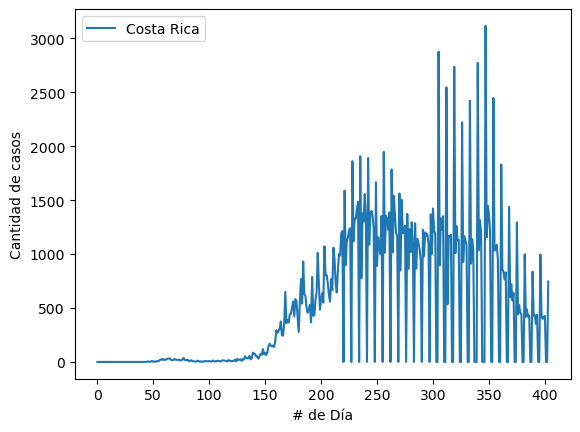

```python
plt.plot(datos['Costa.Rica'], label="Costa Rica")
plt.legend(loc="upper left")
plt.xlabel('# de Día')
plt.ylabel('Cantidad de casos')
plt.show()
```

## Parte e

hacer un gráﬁco usando un trazo continuo con pentágonos, que muestre los valores de España, Italia y Francia en el período fechas indicado. La selección debe ser con ‘iloc’. El trazo y los pentágonos en colores diferentes, además debe aportar una leyenda que no interﬁera con los gráﬁcos.

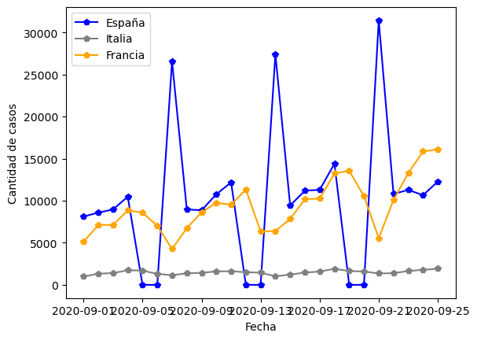

```python
datos2.iloc[222:247,[162,85,62]] #Se efectua la seleccion de las celdas solicitadas en el enunciado
datos3 = datos2.iloc[222:247,[162,85,62]] # Este DF contiene los paises España, Italia y Francia
plt.plot(datos3['Spain'], '-p', color='blue', label='España')
plt.plot(datos3['Italy'], '-p', color='gray', label='Italia')
plt.plot(datos3['France'], '-p', color='orange', label='Francia')
plt.legend(loc="upper left")
plt.xlabel('Fecha')
plt.ylabel('Cantidad de casos')
plt.show()
```